# Personal activity data assignment

Sebastian Schmeck

23 November 2017

0. Overview

Using devices such as Jawbone Up, Nike FuelBand, and Fitbit it is now possible to collect a large amount of data about personal activity relatively inexpensively. These type of devices are part of the quantified self movement - a group of enthusiasts who take measurements about themselves regularly to improve their health, to find patterns in their behavior, or because they are tech geeks.

One thing that people regularly do is quantify how much of a particular activity they do, but they rarely quantify how well they do it. In this project, your goal will be to use data from accelerometers on the belt, forearm, arm, and dumbell of 6 participants. They were asked to perform barbell lifts correctly and incorrectly in 5 different ways. More information is available from the website here: http://groupware.les.inf.puc-rio.br/har (see the section on the Weight Lifting Exercise Dataset).

0. Load Data

Loading two files from the website.

```r
pml_training <- read.csv(url("https://d396qusza40orc.cloudfront.net/predmachlearn/pml-training.csv"))
pml_testing <- read.csv(url("https://d396qusza40orc.cloudfront.net/predmachlearn/pml-testing.csv"))
```

1. Data Preparation

First Parameter “Classe” is changed from character to factor. Then columns with NAs are deleted.

```r
library(caret)
library(AppliedPredictiveModeling)
pml_training$classe <- as.factor(pml_training$classe)
summary(pml_training$classe)
```

```
##    A    B    C    D    E
## 5580 3797 3422 3216 3607
```

```r
pml_training <- pml_training[,-c(12:36)]
pml_training <- pml_training[,-c(25:34)]
pml_training <- pml_training[,-c(34:48)]
pml_training <- pml_training[,-c(37:51)]
pml_training <- pml_training[,-c(38:47)]
pml_training <- pml_training[,-c(50:64)]
pml_training <- pml_training[,-c(51:60)]
pml_training <- pml_training[,-c(46,58,59)]

sum(is.na(pml_training))
```

```
## [1] 0
```

2. Split Training data

Training data are split 50% to train, 50% to test data.

```r
    adData = data.frame(pml_training)
    trainIndex = createDataPartition(pml_training$classe, p = 0.50,list=FALSE)
    train = adData[trainIndex,]
    test = adData[-trainIndex,]
```

3. Train a model

As method “rpart” is used to train a classification. It uses recursive partitioning for classification.

```r
set.seed(123)
    trainedmodel <- train(classe ~ ., train, method = "rpart")
```

4. Plot model

The model is plotted. As you can see only the classses A, B and E can be reached.

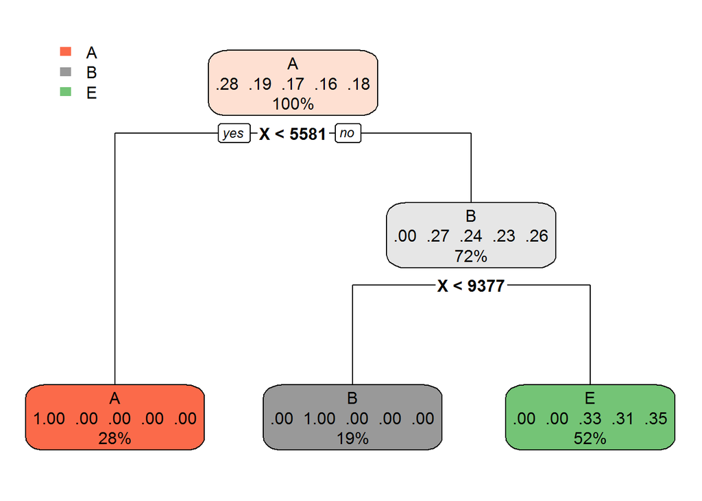

```r
library(rpart.plot)
    rpart.plot(trainedmodel$finalModel)
```

5. Predict on train data set

Using the prediction on the train data set gives a confusion matrix with an accuracy of 0.66.

```r
 predicted <- predict(trainedmodel, train)
confusionMatrix(train$classe, predicted)
```

```
## Confusion Matrix and Statistics
##
##           Reference
## Prediction    A    B    C    D    E
##          A 2790    0    0    0    0
##          B    0 1899    0    0    0
##          C    0    0    0    0 1711
##          D    0    0    0    0 1608
##          E    0    0    0    0 1804
##
## Overall Statistics
##
##                Accuracy : 0.6617
##                  95% CI : (0.6523, 0.6711)
##     No Information Rate : 0.5221
##     P-Value [Acc > NIR] : < 2.2e-16
##
##                   Kappa : 0.5695
##  Mcnemar's Test P-Value : NA
##
## Statistics by Class:
##
##                      Class: A Class: B Class: C Class: D Class: E
## Sensitivity            1.0000   1.0000       NA       NA   0.3521
## Specificity            1.0000   1.0000   0.8256   0.8361   1.0000
## Pos Pred Value         1.0000   1.0000       NA       NA   1.0000
## Neg Pred Value         1.0000   1.0000       NA       NA   0.5855
## Prevalence             0.2843   0.1935   0.0000   0.0000   0.5221
## Detection Rate         0.2843   0.1935   0.0000   0.0000   0.1839
## Detection Prevalence   0.2843   0.1935   0.1744   0.1639   0.1839
## Balanced Accuracy      1.0000   1.0000       NA       NA   0.6761
```

6. Predict on test data set (cross-validation)

For the prediction on the test data set the confusion matrix changes only sligthly, therefor the accuracy keeps the same at 0.66.

```r
predicted2 <- predict(trainedmodel, test)
confusionMatrix(test$classe, predicted2)
```

```
## Confusion Matrix and Statistics
##
##           Reference
## Prediction    A    B    C    D    E
##          A 2790    0    0    0    0
##          B    0 1897    0    0    1
##          C    0    0    0    0 1711
##          D    0    0    0    0 1608
##          E    0    0    0    0 1803
##
## Overall Statistics
##
##                Accuracy : 0.6616
##                  95% CI : (0.6521, 0.6709)
##     No Information Rate : 0.5222
##     P-Value [Acc > NIR] : < 2.2e-16
##
##                   Kappa : 0.5693
##  Mcnemar's Test P-Value : NA
##
## Statistics by Class:
##
##                      Class: A Class: B Class: C Class: D Class: E
## Sensitivity            1.0000   1.0000       NA       NA   0.3519
## Specificity            1.0000   0.9999   0.8256   0.8361   1.0000
## Pos Pred Value         1.0000   0.9995       NA       NA   1.0000
## Neg Pred Value         1.0000   1.0000       NA       NA   0.5854
## Prevalence             0.2844   0.1934   0.0000   0.0000   0.5222
## Detection Rate         0.2844   0.1934   0.0000   0.0000   0.1838
## Detection Prevalence   0.2844   0.1935   0.1744   0.1639   0.1838
## Balanced Accuracy      1.0000   0.9999       NA       NA   0.6760
```

7. Expected out-of-sample error

The expected out-of-sample error is calculated as 1 - accuracy for predictions made against the cross-validation set.

Accuracy = 0.66

-> out-of-sample error = 1- Accuracy = 0.34